# osmar: OpenStreetMap and R

#### Subset.

The return value of the find functions then can be used to create subsets of `osmar` objects. The `subset()` method for `osmar` objects takes element IDs and returns the corresponding data as `osmar` objects. For example, the two subsets based on the traffic signal and bus stop element IDs are:

```r
> ts <- subset(ua, node_ids = ts_ids)
> ts
```

```r
osmar object
25 nodes, 0 ways, 0 relations
```

```r
> bs <- subset(ua, node_ids = bs_ids)
> bs
```

```r
osmar object
15 nodes, 0 ways, 0 relations
```

The subset based on the highway element IDs is:

```r
> hw <- subset(ua, ids = hw_ids)
> hw
```

```r
osmar object
1321 nodes, 253 ways, 0 relations
```

Note that the subsetting of `osmar` objects is divided into the two steps “finding” and “subsetting” to have more flexibility in handling the related elements (here with using `find_down()` and `find_up()`, but more sophisticated routines can be imagined).

#### Plot.

The visualization of `osmar` objects is possible if nodes are available in the object (as only these OSM elements contain latitude and longitude information). The functions `plot_nodes()` and `plot_ways()` plot the available nodes as dots and ways as lines, respectively. The `plot()` method combines these two function calls. Note that this is a plot of the raw data and no projection is done (see the following section for a projected visualization).

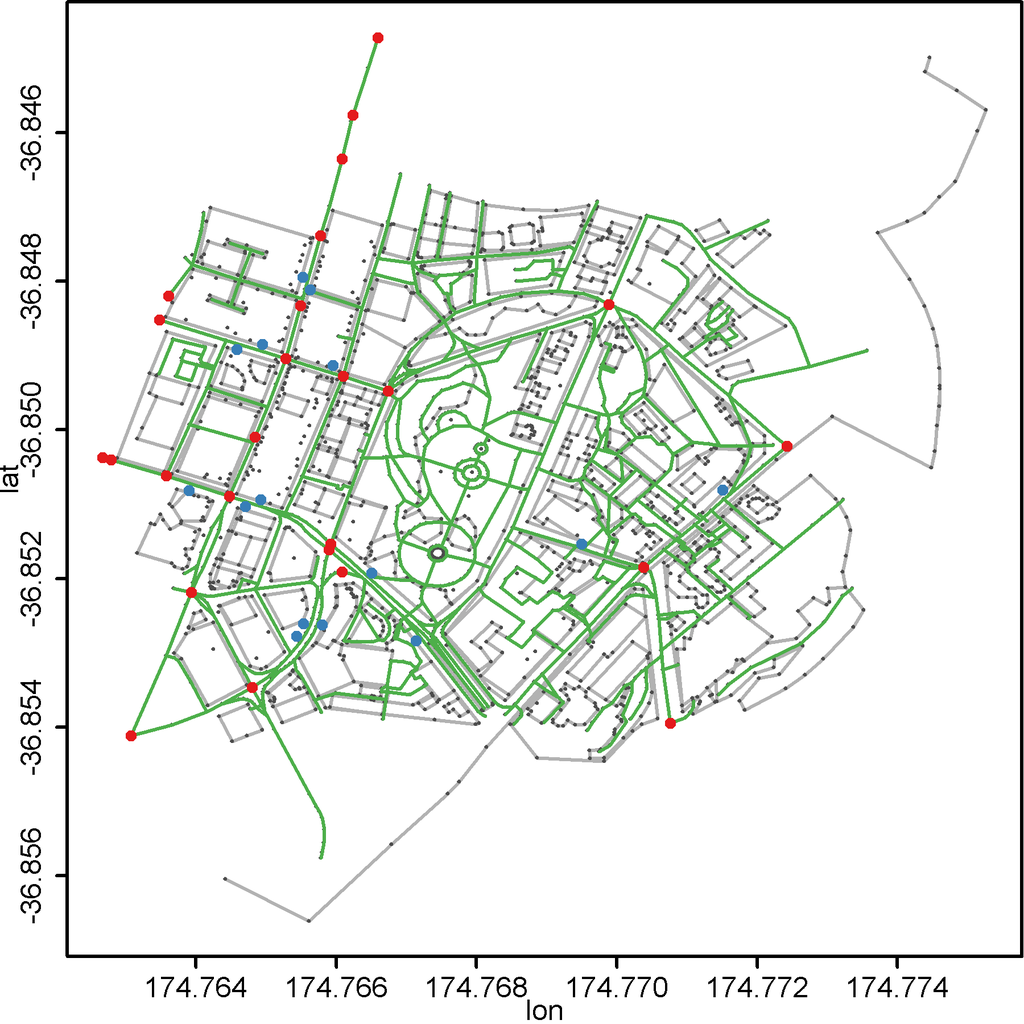

Figure 2: University of Auckland; roads are green lines; bus stops are blue and traffic signals are red points.

```r
> plot(ua)
> plot_ways(hw, add = TRUE, col = "green")
> plot_nodes(ts, add = TRUE, col = "red")
> plot_nodes(bs, add = TRUE, col = "blue")
```

# Converting the data

In order to use the complete power of R on OpenStreetMap data, it is essential to be able to convert `osmar` objects into commonly used objects based on classes provided by other packages. Currently, *osmar* provides two converters – into the [*sp*](https://CRAN.R-project.org/package=sp) (Bivand, Pebesma, and Gomez-Rubio 2008) and the [*igraph*](https://CRAN.R-project.org/package=igraph) (Csardi 2011) packages. In this section we show the conversion to `sp` objects, the navigation device example shows the conversion to `igraph` objects.

The *sp* package provides special data structures and utility functions for spatial data. Spatial data classes are available for points, lines, and polygons and others (see Bivand, Pebesma, and Gomez-Rubio 2008). The *osmar* package provides the `as_sp()` function,

```r
> args(as_sp)
```

```r
function(obj, what = c("points", "lines", "polygons"),
         crs = osm_crs(), simplify = TRUE)
NULL
```

to convert an `osmar` object into the corresponding classes for points, lines, and polygons in the *sp* package (given the required data are available). Note that the appropriate WGS84 coordinate reference system (CRS) for OpenStreetMap data is used (cf. `osm_crs()`).

#### Polygons.

Polygons are used to represent areas, which OpenStreetMap represents as closed ways. Buildings, for example, are closed ways and can be converted to an `sp` polygon object:

```r
> bg_ids <- find(ua, way(tags(k == "building")))
> bg_ids <- find_down(ua, way(bg_ids))
> bg <- subset(ua, ids = bg_ids)
> bg
```

```r
osmar object
991 nodes, 110 ways, 0 relations
```

```r
> bg_poly <- as_sp(bg, "polygons")
```

The result is a `SpatialPolygonsDataFrame` with the `osmar` object’s attributes (the `attrs` element) as its data. Functionality provided by the *sp* package can now be used to analyze the OSM data; e.g., the `summary()` method or the `spplot()` method—the latter one, for example, to see how often each building was modified:

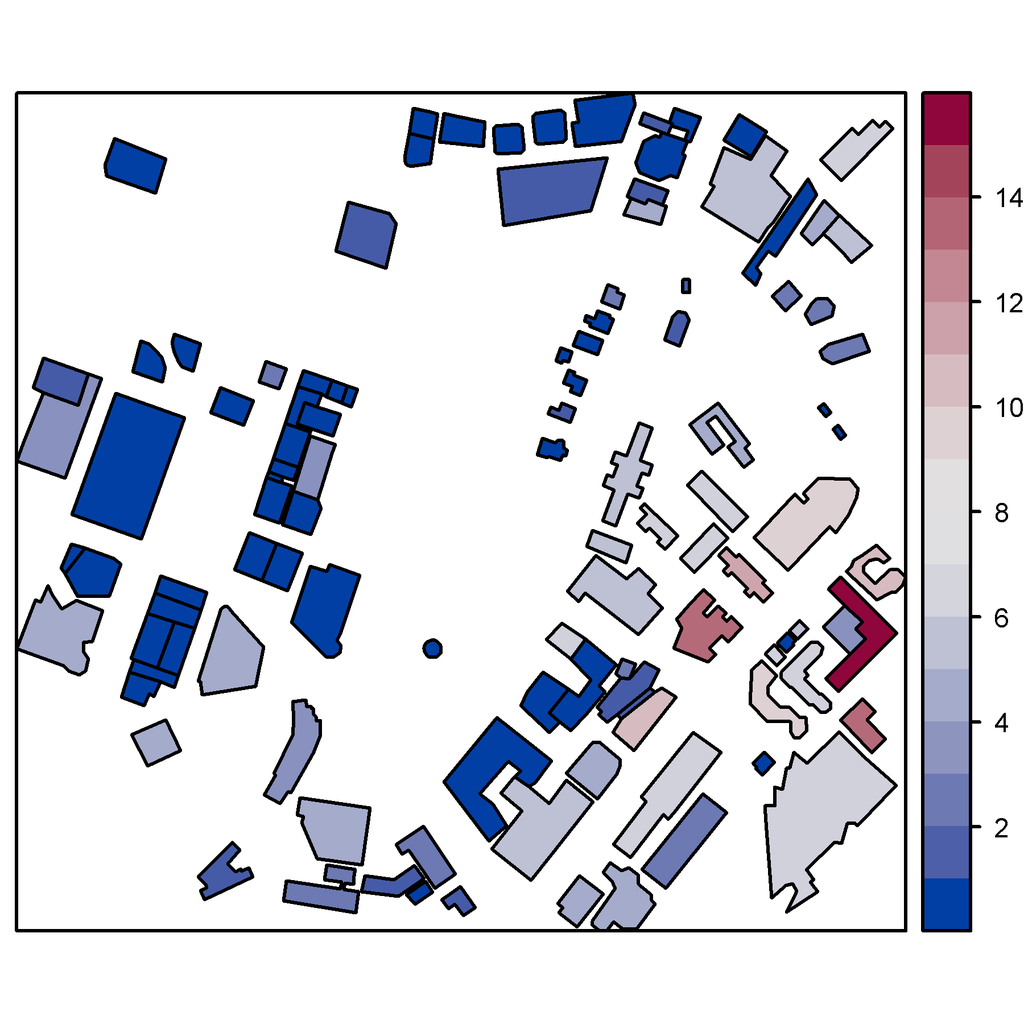

Figure 3: Number of modifications per building.

```r
> spplot(bg_poly, c("version"))
```

Meta-data (the `tags` element) and members (the `refs` element) are not automatically converted to a `SpatialPolygonsDataFrame`’s data.

#### Lines and points.

The conversion of lines and points works similarly:

```r
> hw_line <- as_sp(hw, "lines")
> bs_points <- as_sp(bs, "points")
```

The results are `SpatialLinesDataFrame` and `SpatialPointsDataFrame` objects, respectively.

In order to finalize the University of Auckland example we create a bus route map and visualize the available bus routes belonging to the bus stops. Therefore, we find all `bus` relations available in the object, retrieve the corresponding data from the OSM API, and convert the data into lines (note that this computation takes some time):

```r
> bus_ids <- find(ua, relation(tags(v == "bus")))
> bus <- lapply(bus_ids,
+   function(i) {
+     raw <- get_osm(relation(i), full = TRUE)
+     as_sp(raw, "lines")
+   })
```

We use the argument `full = TRUE` to retrieve the relation itself and all related members. In detail, this means we retrieve all nodes, ways, and relations that are members of the specified relation; and, recursively, all nodes that are members of the retrieved ways.

We then use the *sp* plot methods to create the final bus route map:

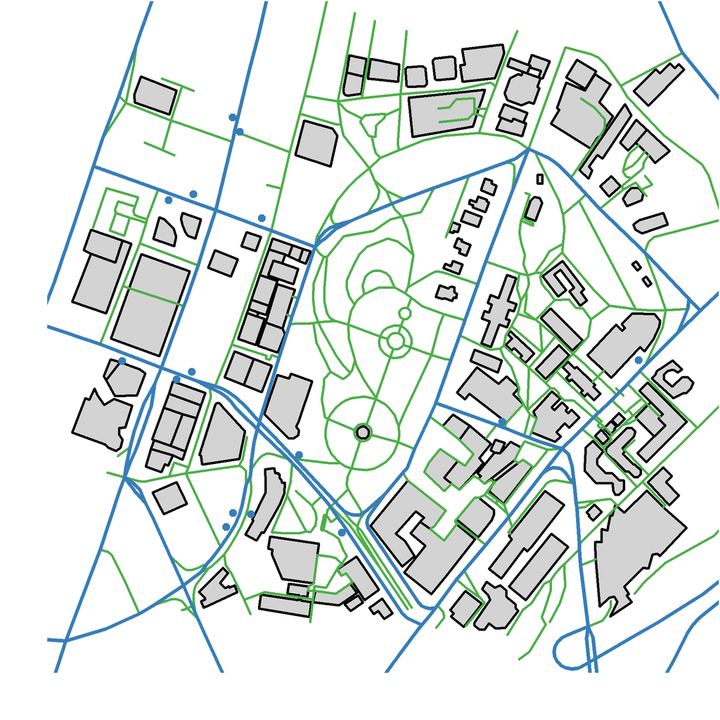

```r
> plot(bg_poly, col = "gray")
> plot(hw_line, add = TRUE, col = "green")
> plot(bs_points, add = TRUE, col = "blue")
> for ( i in seq(along = bus) ) {
+   plot(bus[[i]], add = TRUE, col = "blue")
+ }
```

.

Figure 4: Bus route map of the University of Auckland; roads are green lines; bus stops and bus routes are blue points and lines

# R as navigator

We always wanted to know how a navigation device works. Now with *osmar*, R provides the necessary components and this serves as nice example on how to use *osmar*. The general idea is to (1) get the data, (2) extract all highways, (3) create a graph of all highway nodes with the distance between the highway nodes as edge weights, (4) compute the shortest path on the graph, and (5) trace the path on the highways.

#### Get the data.

We use a planet file from Munich as the data source and use Osmosis (Henderson 2011) to process the data. Note that `osmosis` has to be in your `PATH` environment variable.

```r
> library("osmar")
> url <- "http://osmar.r-forge.r-project.org/"
> file <- "muenchen.osm.gz"
> download.file(sprintf("%s%s", url, file), file)
> system("gzip -d muenchen.osm.gz")
```

Get the center of Munich with a $3\text{km} \times 3\text{km}$ bounding box:

```r
> src <- osmsource_osmosis(file = "muenchen.osm")
> muc_bbox <- center_bbox(11.575278, 48.137222, 3000, 3000)
> muc <- get_osm(muc_bbox, src)
> muc
```

```r
osmar object
13713 nodes, 3156 ways, 76 relations
```

For the navigation device we only need streets. This means, we have to find all ways that are tagged as highways and have a name tag, then find the associated nodes, and finally subset the full `osmar` object:

```r
> hways_muc <- subset(muc, way_ids = find(muc, way(tags(k == "highway"))))
> hways <- find(hways_muc, way(tags(k == "name")))
> hways <- find_down(muc, way(hways))
> hways_muc <- subset(muc, ids = hways)
> hways_muc
```

```r
osmar object
3889 nodes, 995 ways, 0 relations
```

Suppose we want to start our route at the “Sendlinger Tor”. This means we first have to find a node that is tagged with the name “Sendlinger Tor” and then the nearest highway node:

```r
> hway_start_node <- local({
+   id <- find(muc, node(tags(v == "Sendlinger Tor")))[1]
+   find_nearest_node(muc, id, way(tags(k == "highway")))
+ })
> hway_start <- subset(muc, node(hway_start_node))
```

For a given node (by its ID), the function `find_nearest_node()` finds the nearest node with the specified conditions (the package [*geosphere*](https://CRAN.R-project.org/package=geosphere), (Hijmans, Williams, and Vennes 2011) is used to compute the distances). The end of the route should be in the northeast part of Munich; so we find nodes that are in the northeast and take one highway node:

```r
> hway_end_node <- local({
+   id <- find(muc, node(attrs(lon > 11.59 & lat > 48.150)))[1]
+   find_nearest_node(muc, id, way(tags(k == "highway")))
+ })
> hway_end <- subset(muc, node(hway_end_node))
```

Finally, we visualize the initial situation:

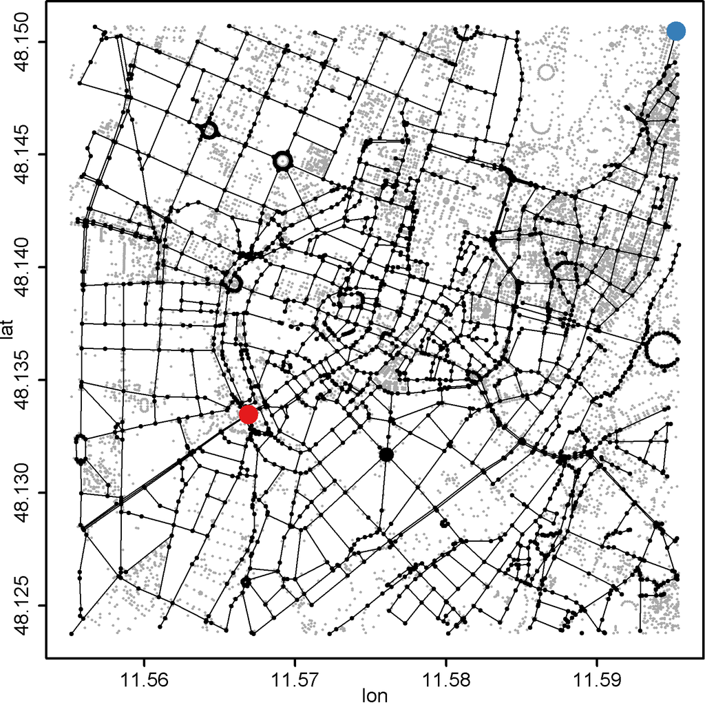

Figure 5: Highway map of Munich center.

```r
> plot_nodes(muc, col = "gray")
> plot_ways(hways_muc, add = TRUE)
> plot_nodes(hways_muc, add = TRUE, col = "black")
> plot_nodes(hway_start, add = TRUE, col = "red")
> plot_nodes(hway_end, add = TRUE, col = "blue")
```

The gray nodes are all nodes available in the full `osmar` object, the black nodes and lines are the road networks available in the highway-`osmar` object, the red and blue dots denote the starting and ending nodes of the searched route.

#### Compute the route.

In order to compute the shortest route between the defined starting and ending nodes, we convert the highway-`osmar` object into a graph. R provides a set of packages to work with graphs, we decided to use *igraph*:

```r
> library("igraph0")
> gr_muc <- as_igraph(hways_muc)
> summary(gr_muc)
```

```r
Vertices: 2381
Edges: 2888
Directed: TRUE
No graph attributes.
Vertex attributes: name.
Edge attributes: weight, name.
```

The `osmar` object nodes define the nodes of the graph (node IDs are used as graph node names). The `osmar` object ways define the edges (way IDs are used as edge names), and the weights of the edges are the geographical distance between the nodes.

The *igraph* package provides different shortest path algorithms (e.g., Dijkstra and Bellman-Ford) via the function `get.shortest.paths()`. The shortest route (not necessarily unique) is:

```r
> route <- get.shortest.paths(gr_muc,
+   from = as.character(hway_start_node),
+   to = as.character(hway_end_node))[[1]]
> route_nodes <- as.numeric(V(gr_muc)[route]$name)
```

We construct a new `osmar` object containing only elements related to the nodes defining the route:

```r
> route_ids <- find_up(hways_muc, node(route_nodes))
> route_muc <- subset(hways_muc, ids = route_ids)
> route_muc
```

```r
osmar object
101 nodes, 83 ways, 0 relations
```

And add the route to the highway map of Munich center in Figure 5:

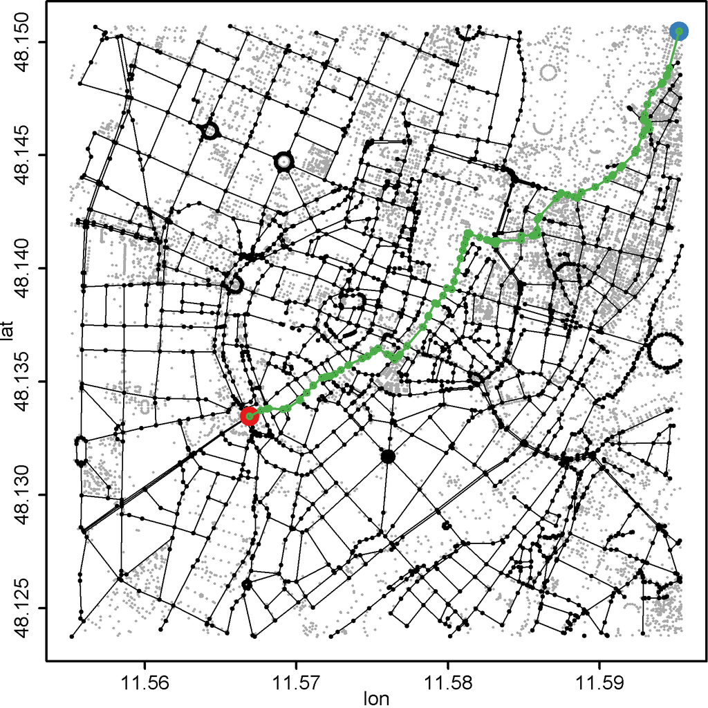

Figure 6: Shortest route on highway map of Munich center.

```r
> plot_nodes(route_muc, add = TRUE, col = "green")
> plot_ways(route_muc, add = TRUE, col = "green")
```

#### Route details.

In order to present route details like street names, distances, and directions we have to work directly on the internals of the `osmar` objects.

We start by extracting the route’s node IDs (which are in the correct order) and the way IDs (which we have to order) where the nodes are members:

```r
> node_ids <- route_muc$nodes$attrs$id
> way_ids <- local({
+   w <- match(node_ids, route_muc$ways$refs$ref)
+   route_muc$ways$refs$id[w]
+ })
```

Then we extract the names of the ways in the correct order:

```r
> way_names <- local({
+   n <- subset(route_muc$ways$tags, k == "name")
+   n[match(way_ids, n$id), "v"]
+ })
```

The next step is to extract the nodes’ coordinates,

```r
> node_coords <- route_muc$nodes$attrs[, c("lon", "lat")]
```

and to compute the distances (meters) and the bearings (degrees) between successive nodes (using the package *geosphere*):

```r
> node_dirs <- local({
+   n <- nrow(node_coords)
+   from <- 1:(n-1)
+   to <- 2:n
+
+   cbind(dist = c(0,
+         distHaversine(node_coords[from, ], node_coords[to, ])),
+         bear = c(0,
+         bearing(node_coords[from, ],
+                 node_coords[to, ])))
+ })
```

Finally, we pack together all the information, and additionally compute the cumulative distance and a 16-point compass rose direction (the `compass()` function is available in the “navigator” demo from the *osmar* package):

```r
> route_details <- data.frame(way_names, node_dirs)
> route_details$cdist <- cumsum(route_details$dist)
> route_details$dir <- compass(route_details$bear)
```

The result is a `data.frame` with a row for each node of the route. The row shows the name of the associated way, the distance (meters) and bearing (degrees and compass rose) to the successive node of the route, and the cumulative distance:

```r
> head(route_details)
```

```r
               way_names dist bear cdist dir
1   Sendlinger-Tor-Platz    0    0     0   N
2             Wallstraße   65   62    65 ENE
3  Herzog-Wilhelm-Straße   29   75    94 ENE
4              Oberanger   10   78   104 ENE
5              Oberanger   69   94   173   E
6     Nikolaus-Gradl-Weg   25   76   198 ENE
```

Needless to say that this navigation device can be made much more sophisticated. The *osmar* package contains the complete source code of the basic navigation device as a demo and we invite everybody to improve R as a navigator.

# Summary

The *osmar* package extends the R ecosystem with infrastructure to work together with the OpenStreetMap project. So far, functionality is available to get data from different sources (e.g., planet file and API v0.6), to consolidate the data as an R `osmar` object, to work with the `osmar` object (e.g., subsetting and plotting), and to convert it to objects based on classes provided by other packages (e.g., to `igraph` and `sp` objects).

Future work includes the implementation of further converters; e.g., a converter from `osmar` objects to raster image objects via the *OpenStreetMap* package. We are also interested in implementing converters from objects provided by other R packages to `osmar` objects and in saving these objects in different OpenStreetMap sources via a `put_osm()` function. This would be, in fact, the completion of the *osmar* concept illustrated in Figure 1 with arrows from the right to the left blocks.

Furthermore, we would like to incorporate tools originated in the OpenStreetMap ecosystem. One idea is the implementation of a rule-based rendering tool for generating SVG images of OSM data along the lines of Osmarender (Jochen Topf 2011). Another interesting project is Osmium, a fast and flexible C++ and Javascript toolkit and framework for working with OSM data (J. Topf 2012). An R interface [potentially via [*Rcpp*](https://CRAN.R-project.org/package=Rcpp) modules; Eddelbuettel and François (2011)] would provide a very fast and flexible way to work with large OSM data sets.

# Acknowledgment

The authors thank two anonymous reviewers and Joe Sakshaug for their constructive comments to improve the manuscript.

Bivand, Roger S., Edzer J. Pebesma, and Virgilio Gomez-Rubio. 2008. *Applied Spatial Data Analysis with R*. Springer, NY. http://www.asdar-book.org/.

Csardi, Gabor. 2011. *igraph: Network Analysis and Visualization*. http://cran.r-project.org/package=igraph.

Eddelbuettel, Dirk, and Romain François. 2011. “Rcpp: Seamless R and C++ Integration.” *Journal of Statistical Software* 40 (8): 1–18. http://www.jstatsoft.org/v40/i08/.

Fellows, Ian. 2012. *OpenStreetMap: Access to OpenStreetMap Raster Images*. http://CRAN.R-project.org/package=OpenStreetMap.

Henderson, Brett. 2011. *osmosis*. http://wiki.openstreetmap.org/wiki/Osmosis.

Hijmans, Robert J., Ed Williams, and Chris Vennes. 2011. *geosphere: Spherical Trigonometry*. http://CRAN.R-project.org/package=geosphere.

Kahle, David, and Hadley Wickham. 2012. *ggmap: A Package for Spatial Visualization with Google Maps and OpenStreetMap*. http://CRAN.R-project.org/package=ggmap.

Loecher, Markus. 2012. *RgoogleMaps: Overlays on Google Map Tiles in R*. http://CRAN.R-project.org/package=RgoogleMaps.

OSM Foundation. 2011. *The OpenStreetMap Project*. http://openstreetmap.org.

Schlesinger, Thomas, and Manuel J. A. Eugster. 2012. *osmar: OpenStreetMap and R*. http://cran.r-project.org/package=osmar.

Topf, J. 2012. *Osmium,* . Fast; flexible C++; Javascript toolkit; framework forworking with OSM data. http://wiki.openstreetmap.org/wiki/Osmium.

Topf, Jochen. 2011. *osmarender*. http://wiki.openstreetmap.org/wiki/Osmarender.